# Are consumer sleep trackers accurate?

A statistical comparison of 3 leading devices

Nicholas Wisniewski

5/8/2019

Abstract

We compared 3 sleep trackers and their ability to measure total sleep, deep sleep, REM sleep, and light sleep. We found significant differences across devices for all 4 measurements. Furthermore, we found no correlation between the amount of deep sleep measured by the 3 devices, and low correlation between REM sleep measurements. We concluded that current sleep trackers are only capable of measuring total sleep.

# 1 Introduction

Consumer sleep trackers are becoming more popular, but little is known about their accuracy. Most trackers today claim to be able to distinguish between light sleep, deep sleep, and REM sleep – a claim that would now make it possible to quantitatively claim, among other things, whether or not you had [too much to dream last night](https://www.youtube.com/watch?v=IeVnbAfcwv8). In order to estimate the amount of agreement between the most cutting-edge trackers on the market, we compared simultaneous data taken from three sleep trackers – the [Fitbit Charge 3](https://www.fitbit.com/charge3), [Oura Ring](https://ouraring.com/returns/) and the [Withings Sleep](https://www.withings.com/us/en/sleep).

- The Fitbit Charge 3 is the latest flagship of the established brand. It uses a green light to obtain an optical pulse waveform, which allows it to track heart rate, inter-beat-intervals, and motion. Machine learning is then used to calculate sleep stages.
- The Oura Ring also measures an optical pulse waveform, and claims to detect pulse rate, inter-beat-intervals, and pulse amplitude, respiratory rate, motion, and body temperature. Machine learning is then used to calculate sleep stages.
- The Withings Sleep is a mat sensor that is placed beneath the mattress. It uses ballistocardiography to detect your heart beating, respiratory rate, snoring, and any other movement. Again, nothing is known about the machine learning algorithm.

At the time of evaluation, the Oura ring over twice as expensive as the others, with an asking price of $\$300$ compared to the Fitbit Charge 3 at $\$150$ and the Withings Sleep at $\$100$. Fitbit is based on San Francisco, Oura is based out of Oulu, Finland, and Withings is located in Issy-les-Moulineaux, France.

## 1.1 Validation Studies

Early sleep trackers were strictly accelerometer-based, and several [studies](https://www.livescience.com/42710-fitness-trackers-sleep-monitoring-accuracy.html) raised concerns about accuracy. In a 2011 study, Montgomery-Downs and colleagues compared simultaneous recordings from an accelerometer-based tracker (the Fitbit) to polysomnography, finding that the Fitbit overestimated the time participants were asleep by $67 \min$ on average. A 2013 study using the Fitbit One found an opposite effect, underestimating by $109$ minutes on average in a cohort of children.

A more recent review of consumer wearables, including ones that can track heart rate, was published by [Peake et al.](https://www.ncbi.nlm.nih.gov/pmc/articles/PMC6031746/) in June 2018. They estimated that only $5\%$ of the technologies currently available have been formally validated; over half included in the review had not been independently tested. In their review of sleep trackers, only $3/21 (14\%)$ of devices had been validated: the Oura Ring (which, at the time, was not yet commercially available); the UP by Jawbone (which has since liquidated), and the FitBit Charge2. None of these had undergone reliability testing, and the Withings Sleep device was not available at the time of the review (the most similar device was the Beddit3, which was also not validated).

### 1.1.1 Jawbone UP

A validation study of the Jawbone UP by [de Zambotti et al.](https://www.ncbi.nlm.nih.gov/pmc/articles/PMC4780439/) found that the device had high sensitivity for detecting sleep ($97\%$) and low specificity for detecting wake ($37\%$), and it overestimated total sleep time ($26.6 \pm 35.3 \min$). [Gruwez et al.](https://www.ncbi.nlm.nih.gov/pubmed/28495352) reported that measurments of total sleep time correlated at $r=0.63$, but did not correlate with measurements of deep sleep, light sleep, or sleep efficiency. Jawbone ceased production in 2016, and has since gone out of business and liquidated.

### 1.1.2 FitBit Charge 2

A validation study of the FitBit Charge2 by [de Zambotti et al.](https://www.ncbi.nlm.nih.gov/pubmed/29235907) looked at 44 adults, and reported $96\%$ sensitivity (accuracy to detect sleep), $61\%$ specificity (accuracy to detect wake), $81\%$ accuracy in detecting light sleep, $49\%$ accuracy in detecting deep sleep, and $74\%$ accuracy in detecting REM sleep. It overestimated total sleep by $9 \min$, overestimated light sleep by $34 \min$, and underestimated deep sleep by $24 \min$. Times in REM sleep appeared accurate. The author’s conclusion was that:

> Fitbit Charge 2™ shows promise in detecting sleep-wake states and sleep stage composition relative to gold standard PSG, particularly in the estimation of REM sleep, but with limitations in deep sleep detection.

### 1.1.3 Oura Ring

Oura currently markets itself as “the most accurate sleep and activity tracker,” though the basis of this claim is not clear. A validation study of the Oura Ring by [de Zambotti et al.](https://www.ncbi.nlm.nih.gov/pmc/articles/PMC6095823/) looked at $41$ people, and reported agreement in the total sleep time, sleep latency onset, and wake after sleep onset (all within $\leq 30 \min$. It had high sensitivity for detecting sleep ($0.96$), but low sensitivity for detecting light sleep ($65\%$), deep sleep ($51\%$), and REM sleep ($61\%$), and poor specificity for detecting wake ($48\%$). It was found to underestimate deep sleep by $\sim 20 \min$, and overestimate REM by $\sim 17 \min$.

## 1.2 Expected values

How much sleep is normal, and how is it divided across sleep states? According to the National Sleep Foundation, a typical adult is recommended between 7-9 hours of sleep (420-540 minutes), though 6-10 hours (360-600 minutes) may be appropriate. [Merica and Gaillard](https://academic.oup.com/sleep/article/8/3/261/2751161) (1985) studied 147 adults with no known pathology for a total of 399 nights of sleep, in order to provide an accurate description of the amount of time spent in each sleep cycle. The sleep stages, at that time, were divided into 5 stages (stage 1-4 non-REM, and REM). Today, stages 3 & 4 are usually combined, as follows:

- Stage 1 is the transition period between wakefulness and sleep.
- Stage 2 is when sleep spindles occur. People spend around 50% of their total sleep in this stage.
- Stage 3 & 4 is deep, slow wave (delta) sleep.
- PS is paradoxical sleep, or REM sleep.

A brief summary of their results is tabulated below:

| stage | mean | sd |
| --- | --- | --- |
| **total sleep** |  |  |
| total | 480.4 | 45.5 |
| **light sleep** |  |  |
| Stage 1 | 27.5 | 25.1 |
| Stage 2 | 253.7 | 46.5 |
| subtotal | 281.2 | 52.8 |
| **deep sleep** |  |  |
| Stage 3 | 39.9 | 21.3 |
| Stage 4 | 54.1 | 39.1 |
| subtotal | 94.0 | 44.5 |
| **rem sleep** |  |  |
| subtotal | 105.3 | 24.8 |

# 2 Methods

Data was taken from a single subject for 36 nights between 2019-05-03 and 2019-06-07, at a single location. Data was recorded simultaneously using the Fitbit Charge 3, Oura Ring and Withings Sleep monitor. The Fitbit was only included in the study 2 weeks after it began – it therefore has fewer recordings than the other devices.

If sleep trackers are accurate, they should produce similar values for each of the sleep states. In order to test the hypothesis that all 3 devices produce similar values, we compared average measurements of deep sleep, REM sleep, light sleep, and total sleep, using a linear mixed effect model (in the `lmerTest` R package). We performed all post-hoc pairwise comparisons based on this model using the `emmeans` package, and corrected for multiple testing by controlling the false discovery rate.

It is possible for the values produced by different devices to disagree on average, yet still provide useful information. For example, a device can underestimate total sleep, but if it is off by a consistent amount then the relative ranking of times should remain the same. However, if the rankings between devices are different (i.e. statistically independent), then the devices cannot claim to reliably measure a particular quantity. In order to test the hypothesis of statistical independence, we computed the Spearman rank correlation between measurements from different devices.

# 3 Results

## 3.1 Raw data

We show the raw in the figures below. Normal ranges as measured by Merica and Gaillard (1985) are shown by the grey-shaded areas and red lines, where the solid line is the normal mean, and the shaded regions/dashed lines are 1 and 1.96 times the normal standard deviation away.

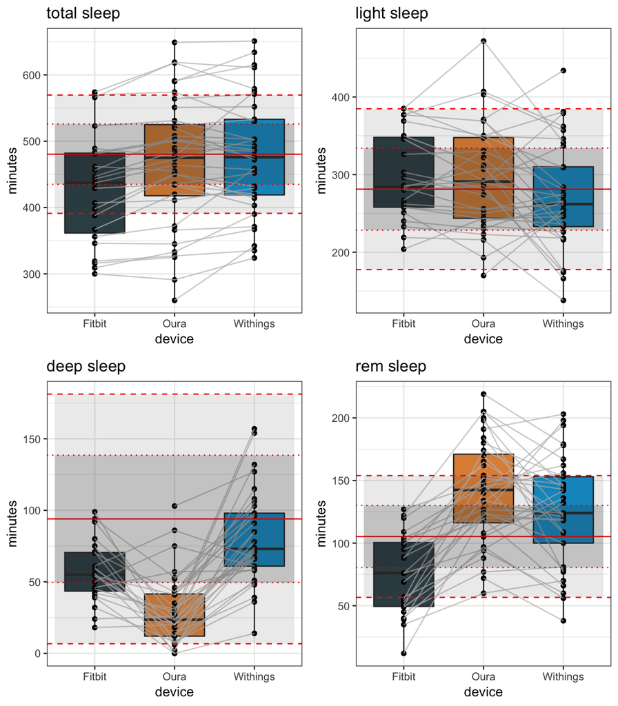

## 3.2 Linear mixed-effect model

### 3.2.1 Pairwise comparisons

We modeled the data using a linear mixed effect model, with a random intercept for each night of sleep. We computed statistical significance for pairwise comparisons between devices by applying the `emmeans` package to the linear mixed effect model. Nominal p-values were adjusted to Benjamini-Hochberg q-values in order to control the false discovery rate. Results with $q<0.05$, corresponding to a 5% false discovery rate, are shown in red.

| contrast | estimate | SE | df | t.ratio | p.value | q.value |
| --- | --- | --- | --- | --- | --- | --- |
| **total sleep** |  |  |  |  |  |  |
| Fitbit - Oura | -23.1 | 6.4 | 54.4 | -3.60 | 0.0007 | 1.36e-03 |
| Fitbit - Withings | -30.0 | 6.6 | 54.5 | -4.51 | 0.0000 | 1.03e-04 |
| Oura - Withings | -6.9 | 5.5 | 54.1 | -1.24 | 0.2200 | 2.40e-01 |
| **light sleep** |  |  |  |  |  |  |
| Fitbit - Oura | 6.8 | 11.1 | 56.7 | 0.61 | 0.5458 | 5.46e-01 |
| Fitbit - Withings | 33.2 | 11.5 | 57.7 | 2.89 | 0.0055 | 8.19e-03 |
| Oura - Withings | 26.5 | 9.7 | 54.6 | 2.72 | 0.0087 | 1.15e-02 |
| **deep sleep** |  |  |  |  |  |  |
| Fitbit - Oura | 28.1 | 6.8 | 62.8 | 4.12 | 0.0001 | 2.74e-04 |
| Fitbit - Withings | -23.3 | 7.0 | 65.5 | -3.34 | 0.0014 | 2.38e-03 |
| Oura - Withings | -51.4 | 6.1 | 56.3 | -8.46 | 0.0000 | 1.58e-10 |
| **rem sleep** |  |  |  |  |  |  |
| Fitbit - Oura | -62.4 | 8.0 | 58.0 | -7.83 | 0.0000 | 7.20e-10 |
| Fitbit - Withings | -46.5 | 8.2 | 59.4 | -5.65 | 0.0000 | 1.89e-06 |
| Oura - Withings | 15.9 | 7.0 | 54.9 | 2.28 | 0.0263 | 3.16e-02 |

### 3.2.2 Device averages

From the linear mixed effect model, we computed estimated marginal means for each device, along with standard errors, and 95% confidence intervals.

| device | emmean | SE | df | lower.CL | upper.CL |
| --- | --- | --- | --- | --- | --- |
| **total sleep** |  |  |  |  |  |
| Fitbit | 444.7 | 15.8 | 41.4 | 412.9 | 476.6 |
| Oura | 467.8 | 15.4 | 37.6 | 436.7 | 498.9 |
| Withings | 474.7 | 15.4 | 38.2 | 443.4 | 505.9 |
| **light sleep** |  |  |  |  |  |
| Fitbit | 303.2 | 12.4 | 73.4 | 278.5 | 327.9 |
| Oura | 296.5 | 10.9 | 55.1 | 274.7 | 318.3 |
| Withings | 270.0 | 11.1 | 58.6 | 247.7 | 292.3 |
| **deep sleep** |  |  |  |  |  |
| Fitbit | 57.5 | 5.6 | 88.9 | 46.3 | 68.6 |
| Oura | 29.3 | 4.5 | 87.0 | 20.5 | 38.2 |
| Withings | 80.8 | 4.7 | 87.6 | 71.5 | 90.0 |
| **rem sleep** |  |  |  |  |  |
| Fitbit | 79.0 | 7.9 | 82.0 | 63.3 | 94.7 |
| Oura | 141.4 | 6.7 | 64.5 | 128.0 | 154.8 |
| Withings | 125.5 | 6.9 | 68.5 | 111.7 | 139.2 |

## 3.3 Device correlations

We computed the Spearman rank correlation between each pair of devices. We corrected for multiple testing by controlling the false discovery rate. Correlation coefficients with $q<0.05$, corresponding to a 5% false discovery rate, are shown in red.

### 3.3.1 Table

| cor | qvalue | row | col |
| --- | --- | --- | --- |
| **total sleep** |  |  |  |
| 0.933 | 3.2e-14 | oura | withings |
| 0.924 | 2.2e-08 | fitbit | withings |
| 0.957 | 6.2e-12 | fitbit | oura |
| **light sleep** |  |  |  |
| 0.578 | 1.0e-03 | oura | withings |
| 0.291 | 2.6e-01 | fitbit | withings |
| 0.896 | 2.2e-08 | fitbit | oura |
| **deep sleep** |  |  |  |
| 0.310 | 1.1e-01 | oura | withings |
| 0.094 | 7.6e-01 | fitbit | withings |
| 0.040 | 8.5e-01 | fitbit | oura |
| **rem sleep** |  |  |  |
| 0.487 | 8.1e-03 | oura | withings |
| 0.463 | 5.9e-02 | fitbit | withings |
| 0.525 | 1.7e-02 | fitbit | oura |

### 3.3.2 Plots

#### 3.3.2.1 total sleep

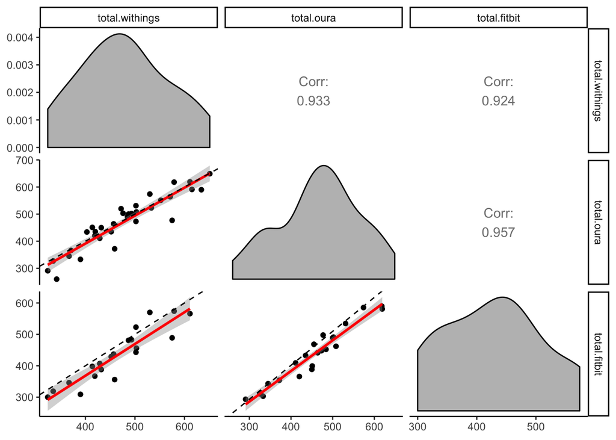

#### 3.3.2.2 light sleep

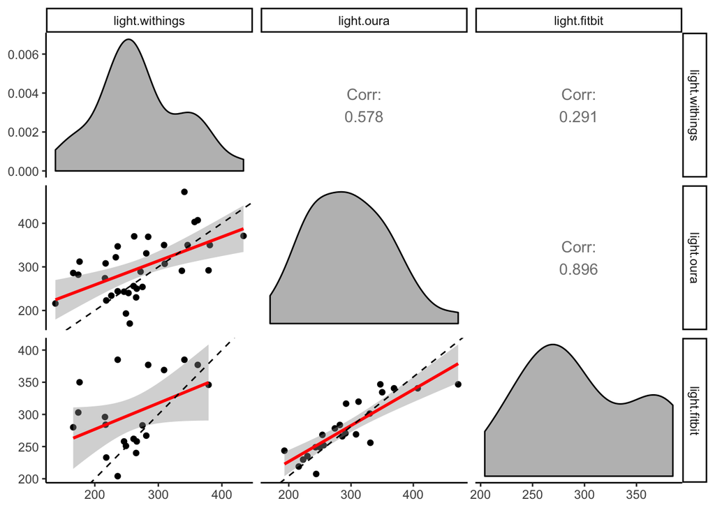

#### 3.3.2.3 deep sleep

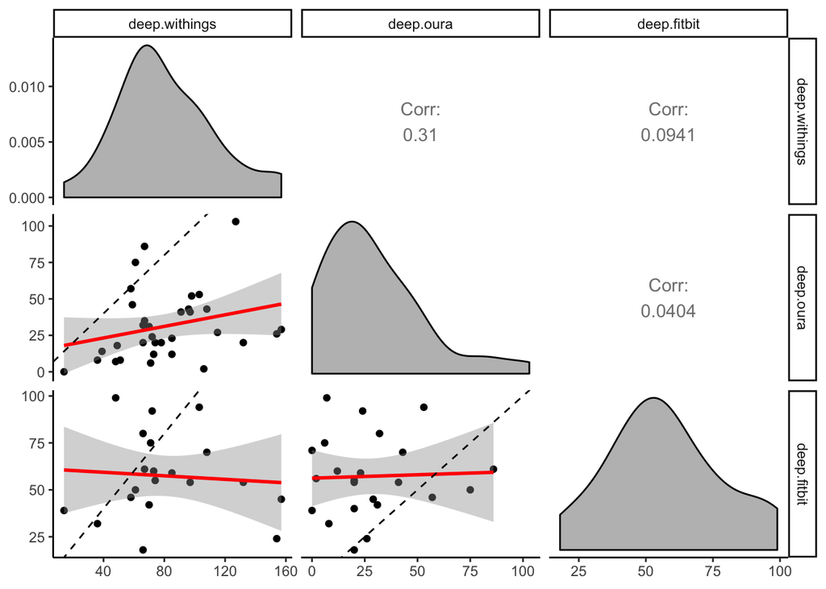

#### 3.3.2.4 rem sleep

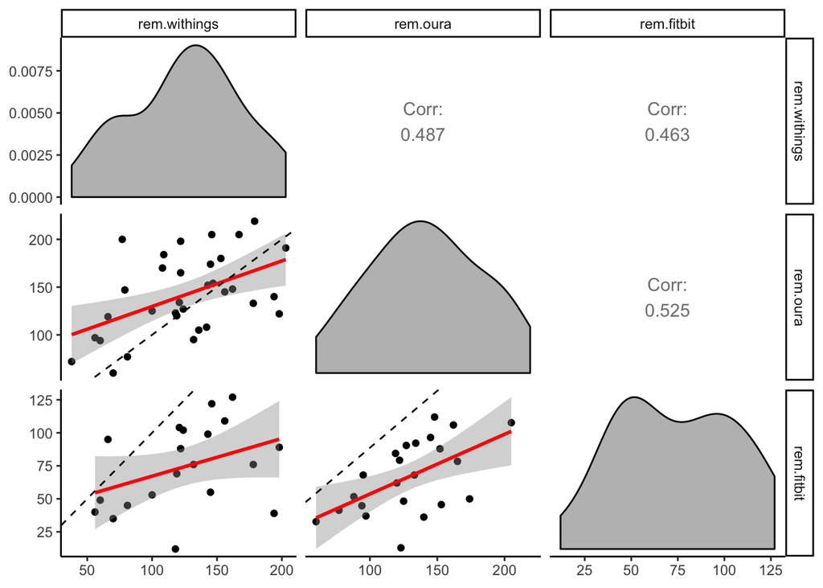

# 4 Discussion

We found significant disagreements in nearly all comparisons between sleep trackers, but particularly large disagreements in the measurements of deep and REM sleep. The Oura Ring measures significantly less deep sleep than the other devices, and significantly more REM sleep than the other devices. Compared to the normal ranges reported by Merica, the Oura’s measurment of REM sleep is unreasonably high (beyond 1 standard deviation), and its measurement of deep sleep is unreasonably low (beyond 1 standard deviation). The Withings measurements were most reasonable in the context of Merica’s data.